# Exam 1

## Exam 1

#### Question

1. En una clase de antropometría, se midió la estatura (en cm) de un grupo de estudiantes. Los datos obtenidos son:

   **Datos de estaturas**

   | 177 | 174 | 183 |
   | --- | --- | --- |
   | 166 | 178 | 176 |
   | 166 | 176 | 172 |
   | 174 | 177 |  |
   | 174 | 168 |  |
   | 174 | 177 |  |
   | 171 | 165 |  |
   | 164 | 183 |  |
   | 164 | 174 |  |
   | 183 | 182 |  |

   ¿Cuál diagrama de caja representa correctamente estos datos?

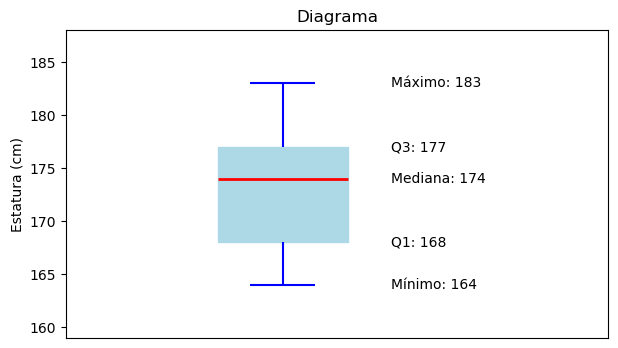

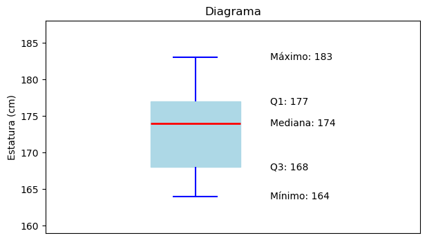

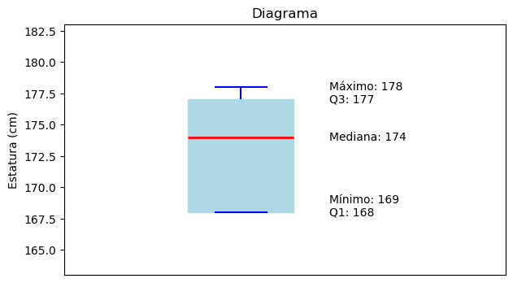

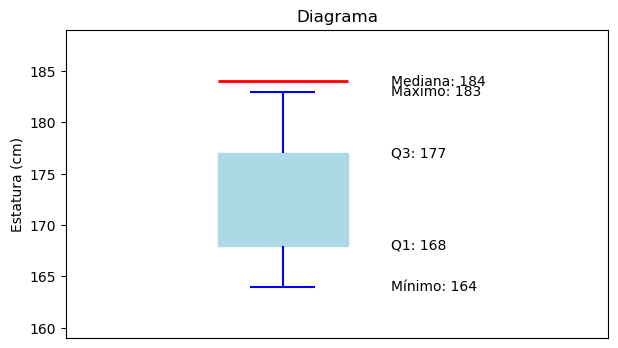

#### Solution

   **Datos de estaturas ordenados**

   | 164 | 174 | 183 |
   | --- | --- | --- |
   | 164 | 174 | 183 |
   | 165 | 174 | 183 |
   | 166 | 176 |  |
   | 166 | 176 |  |
   | 168 | 177 |  |
   | 171 | 177 |  |
   | 172 | 177 |  |
   | 174 | 178 |  |
   | 174 | 182 |  |

   La opción correcta es aquella cuyo diagrama muestra exactamente estos valores:

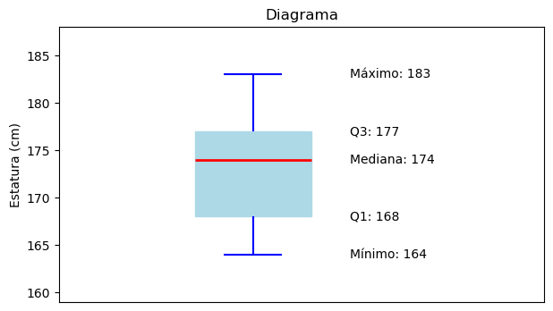

   1. Verdadero
   2. Falso
   3. Falso
   4. Falso

#### Question

2. En una clase de antropometría, se midió la estatura (en cm) de un grupo de estudiantes. Los datos obtenidos son:

   **Datos de estaturas**

   | 167 | 153 | 165 |
   | --- | --- | --- |
   | 178 | 157 | 156 |
   | 168 | 169 | 168 |
   | 173 | 166 |  |
   | 165 | 179 |  |
   | 175 | 176 |  |
   | 177 | 166 |  |
   | 179 | 158 |  |
   | 155 | 150 |  |
   | 152 | 169 |  |

   ¿Cuál diagrama de caja representa correctamente estos datos?

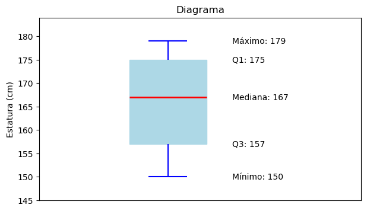

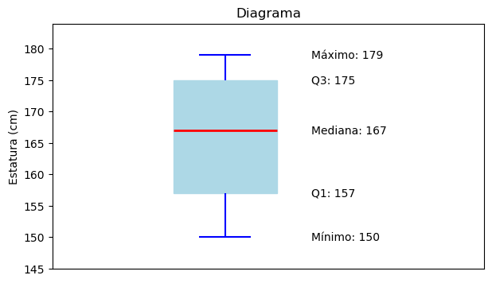

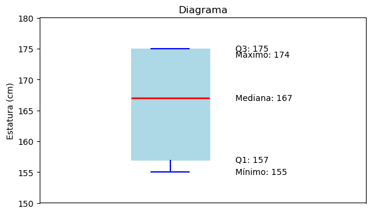

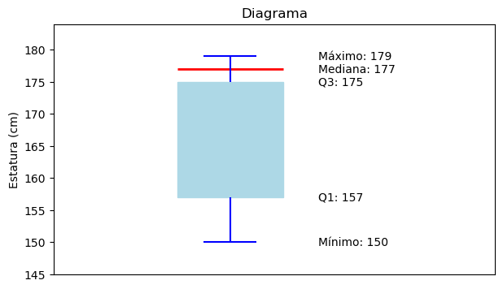

#### Solution

   **Datos de estaturas ordenados**

   | 150 | 166 | 178 |
   | --- | --- | --- |
   | 152 | 167 | 179 |
   | 153 | 168 | 179 |
   | 155 | 168 |  |
   | 156 | 169 |  |
   | 157 | 169 |  |
   | 158 | 173 |  |
   | 165 | 175 |  |
   | 165 | 176 |  |
   | 166 | 177 |  |

   La opción correcta es aquella cuyo diagrama muestra exactamente estos valores:

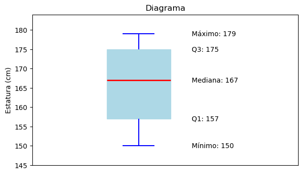

   1. Falso
   2. Verdadero
   3. Falso
   4. Falso

#### Question

3. En una clase de antropometría, se midió la estatura (en cm) de un grupo de estudiantes. Los datos obtenidos son:

   **Datos de estaturas**

   | 167 | 175 |
   | --- | --- |
   | 174 |  |
   | 164 |  |
   | 166 |  |
   | 174 |  |
   | 174 |  |
   | 167 |  |
   | 177 |  |
   | 163 |  |
   | 170 |  |

   ¿Cuál diagrama de caja representa correctamente estos datos?

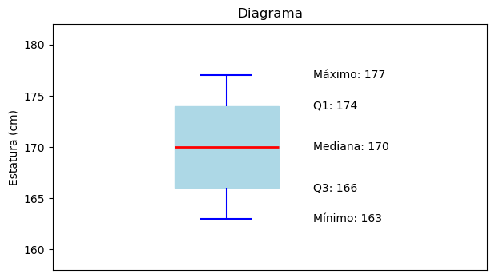

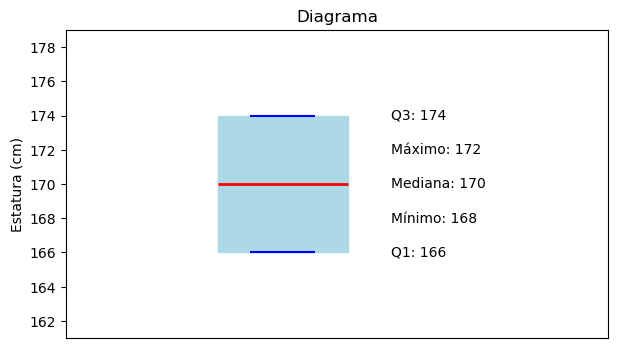

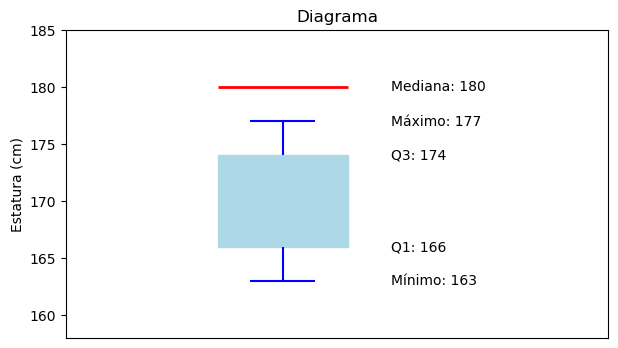

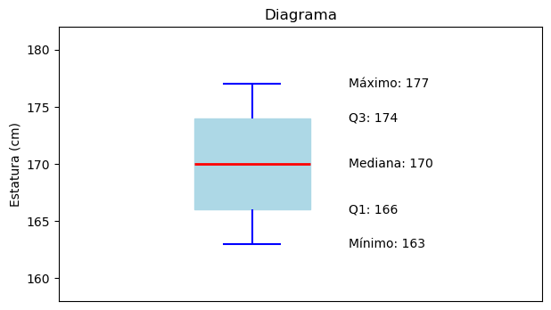

#### Solution

   **Datos de estaturas ordenados**

   | 163 | 177 |
   | --- | --- |
   | 164 |  |
   | 166 |  |
   | 167 |  |
   | 167 |  |
   | 170 |  |
   | 174 |  |
   | 174 |  |
   | 174 |  |
   | 175 |  |

   La opción correcta es aquella cuyo diagrama muestra exactamente estos valores:

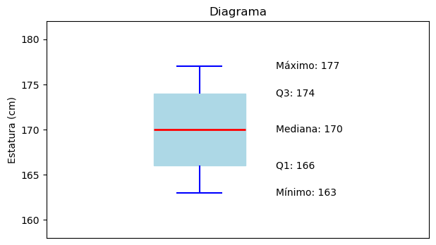

   1. Falso
   2. Falso
   3. Falso
   4. Verdadero

#### Question

4. En una clase de antropometría, se midió la estatura (en cm) de un grupo de estudiantes. Los datos obtenidos son:

   **Datos de estaturas**

   | 160 | 165 | 171 |
   | --- | --- | --- |
   | 156 | 157 | 169 |
   | 162 | 164 |  |
   | 157 | 159 |  |
   | 169 | 173 |  |
   | 165 | 157 |  |
   | 171 | 158 |  |
   | 172 | 158 |  |
   | 161 | 179 |  |
   | 170 | 159 |  |

   ¿Cuál diagrama de caja representa correctamente estos datos?

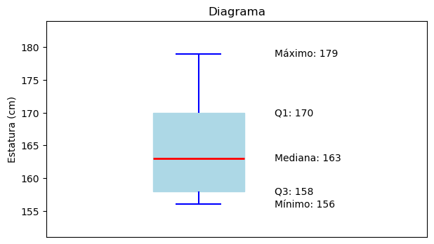

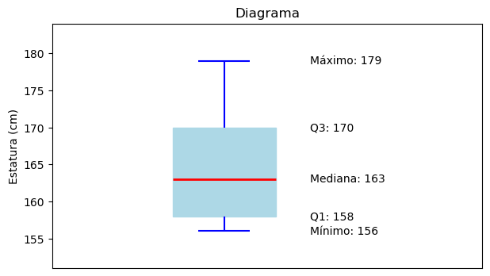

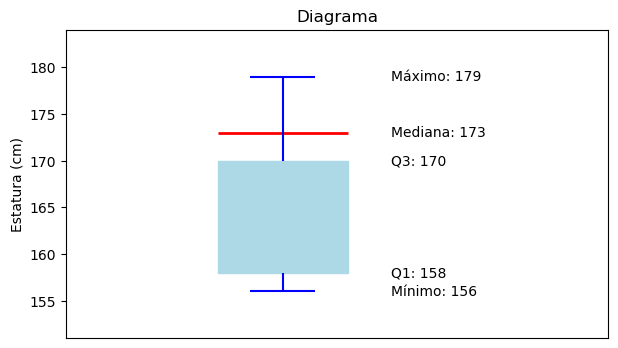

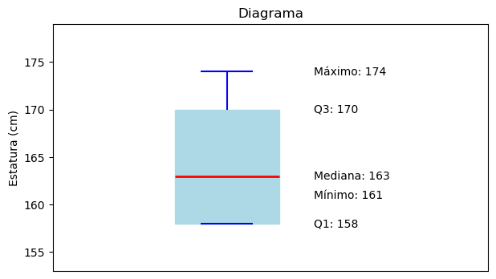

#### Solution

   **Datos de estaturas ordenados**

   | 156 | 162 | 173 |
   | --- | --- | --- |
   | 157 | 164 | 179 |
   | 157 | 165 |  |
   | 157 | 165 |  |
   | 158 | 169 |  |
   | 158 | 169 |  |
   | 159 | 170 |  |
   | 159 | 171 |  |
   | 160 | 171 |  |
   | 161 | 172 |  |

   La opción correcta es aquella cuyo diagrama muestra exactamente estos valores:

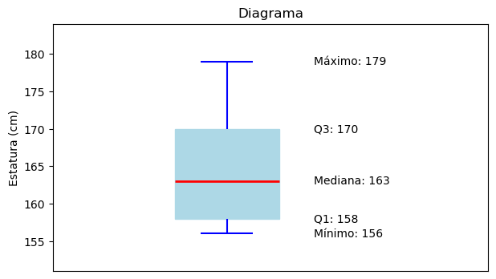

   1. Falso
   2. Verdadero
   3. Falso
   4. Falso

#### Question

5. En una clase de antropometría, se midió la estatura (en cm) de un grupo de estudiantes. Los datos obtenidos son:

   **Datos de estaturas**

   | 175 | 168 |
   | --- | --- |
   | 162 | 150 |
   | 154 | 151 |
   | 168 | 152 |
   | 160 | 173 |
   | 163 | 151 |
   | 162 | 168 |
   | 158 | 152 |
   | 152 | 174 |
   | 157 | 164 |

   ¿Cuál diagrama de caja representa correctamente estos datos?

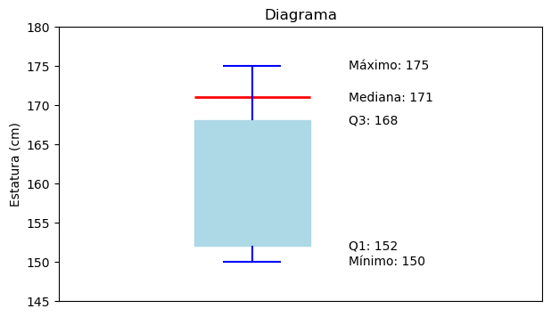

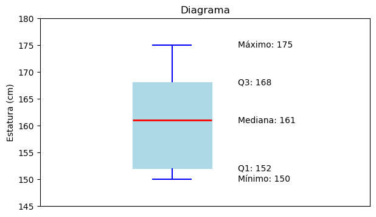

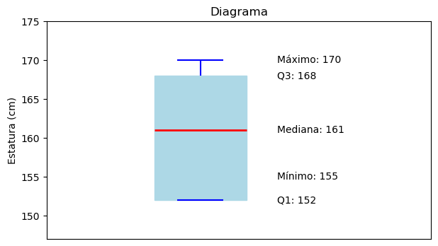

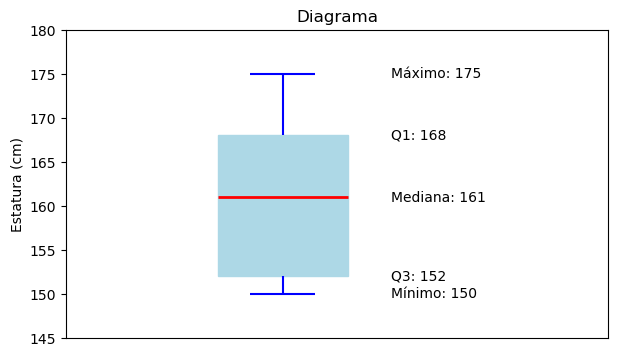

#### Solution

   **Datos de estaturas ordenados**

   | 150 | 162 |
   | --- | --- |
   | 151 | 162 |
   | 151 | 163 |
   | 152 | 164 |
   | 152 | 168 |
   | 152 | 168 |
   | 154 | 168 |
   | 157 | 173 |
   | 158 | 174 |
   | 160 | 175 |

   La opción correcta es aquella cuyo diagrama muestra exactamente estos valores:

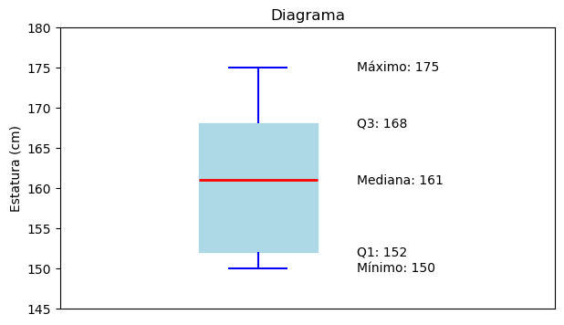

   1. Falso
   2. Verdadero
   3. Falso
   4. Falso

#### Question

6. En una clase de antropometría, se midió la estatura (en cm) de un grupo de estudiantes. Los datos obtenidos son:

   **Datos de estaturas**

   | 156 |
   | --- |
   | 170 |
   | 160 |
   | 170 |
   | 166 |
   | 159 |
   | 165 |
   | 168 |
   | 159 |
   | 158 |

   ¿Cuál diagrama de caja representa correctamente estos datos?

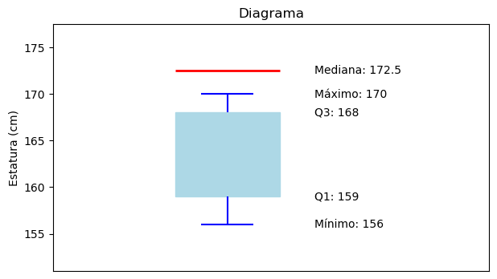

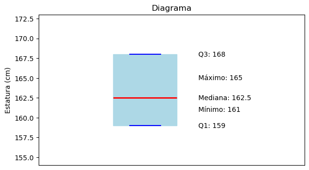

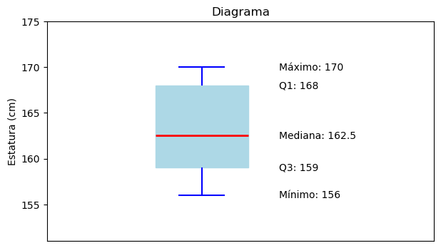

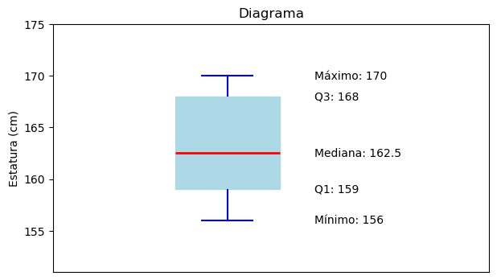

#### Solution

   **Datos de estaturas ordenados**

   | 156 |
   | --- |
   | 158 |
   | 159 |
   | 159 |
   | 160 |
   | 165 |
   | 166 |
   | 168 |
   | 170 |
   | 170 |

   La opción correcta es aquella cuyo diagrama muestra exactamente estos valores:

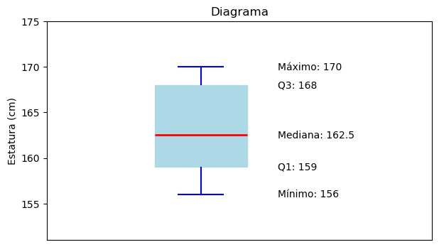

   1. Falso
   2. Falso
   3. Falso
   4. Verdadero

#### Question

7. En una clase de antropometría, se midió la estatura (en cm) de un grupo de estudiantes. Los datos obtenidos son:

   **Datos de estaturas**

   | 162 | 183 |
   | --- | --- |
   | 180 |  |
   | 182 |  |
   | 180 |  |
   | 184 |  |
   | 162 |  |
   | 161 |  |
   | 178 |  |
   | 161 |  |
   | 174 |  |

   ¿Cuál diagrama de caja representa correctamente estos datos?

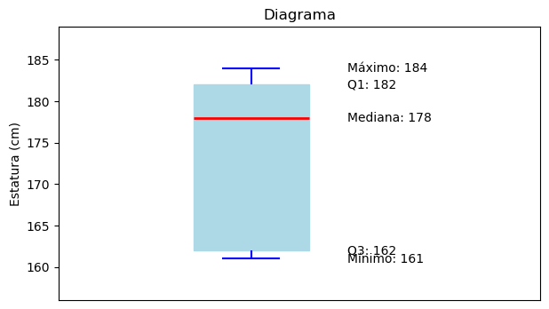

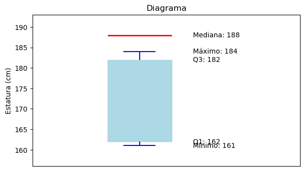

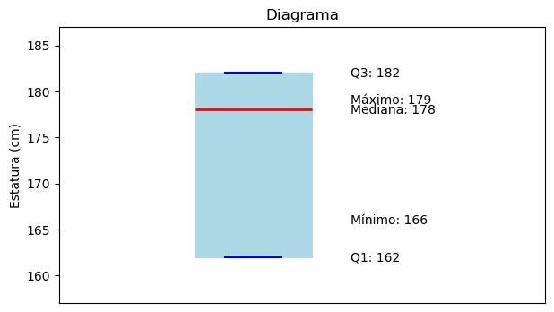

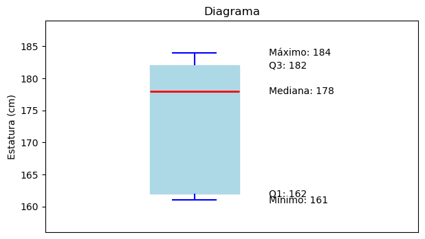

#### Solution

   **Datos de estaturas ordenados**

   | 161 | 184 |
   | --- | --- |
   | 161 |  |
   | 162 |  |
   | 162 |  |
   | 174 |  |
   | 178 |  |
   | 180 |  |
   | 180 |  |
   | 182 |  |
   | 183 |  |

   La opción correcta es aquella cuyo diagrama muestra exactamente estos valores:

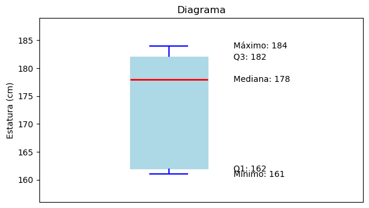

   1. Falso
   2. Falso
   3. Falso
   4. Verdadero

#### Question

8. En una clase de antropometría, se midió la estatura (en cm) de un grupo de estudiantes. Los datos obtenidos son:

   **Datos de estaturas**

   | 161 | 176 |
   | --- | --- |
   | 166 | 170 |
   | 167 | 179 |
   | 167 | 181 |
   | 176 | 179 |
   | 179 | 166 |
   | 160 | 174 |
   | 177 | 178 |
   | 169 | 180 |
   | 172 |  |

   ¿Cuál diagrama de caja representa correctamente estos datos?

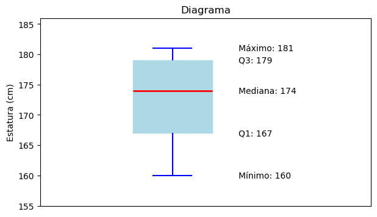

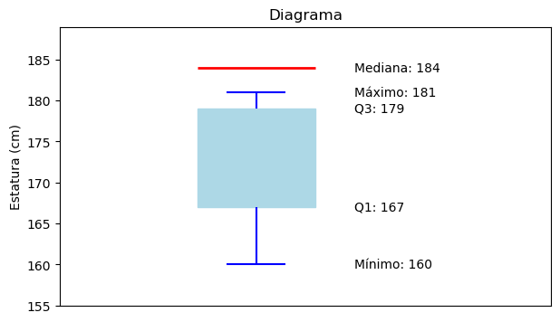

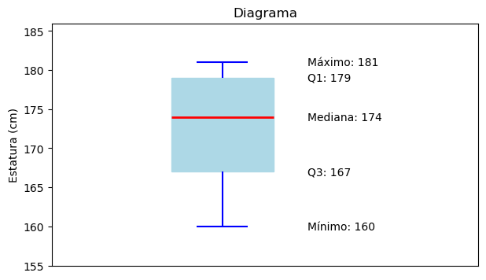

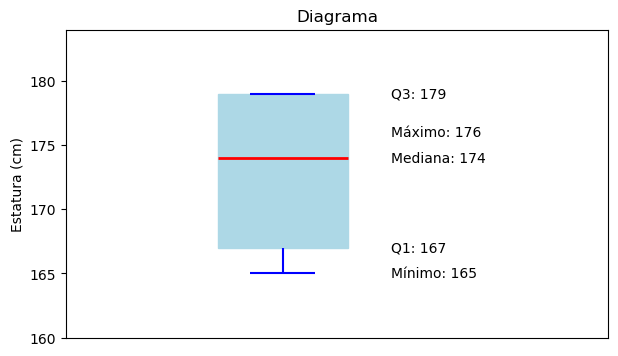

#### Solution

   **Datos de estaturas ordenados**

   | 160 | 176 |
   | --- | --- |
   | 161 | 176 |
   | 166 | 177 |
   | 166 | 178 |
   | 167 | 179 |
   | 167 | 179 |
   | 169 | 179 |
   | 170 | 180 |
   | 172 | 181 |
   | 174 |  |

   La opción correcta es aquella cuyo diagrama muestra exactamente estos valores:

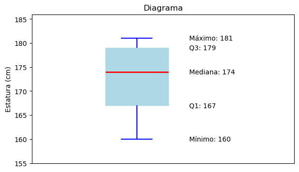

   1. Verdadero
   2. Falso
   3. Falso
   4. Falso

#### Question

9. En una clase de antropometría, se midió la estatura (en cm) de un grupo de estudiantes. Los datos obtenidos son:

   **Datos de estaturas**

   | 175 | 179 |
   | --- | --- |
   | 172 | 167 |
   | 174 | 173 |
   | 181 | 169 |
   | 173 | 168 |
   | 172 | 184 |
   | 177 | 174 |
   | 186 | 168 |
   | 170 | 177 |
   | 180 |  |

   ¿Cuál diagrama de caja representa correctamente estos datos?

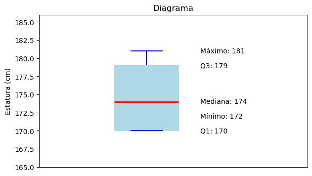

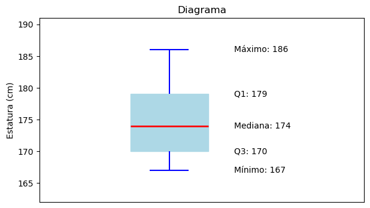

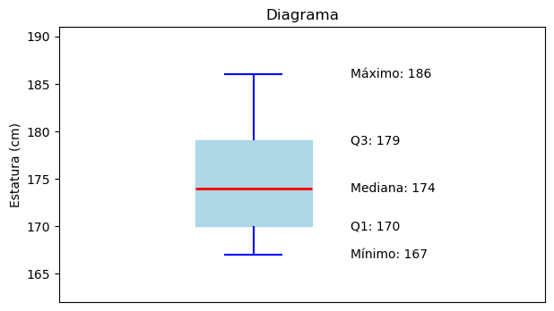

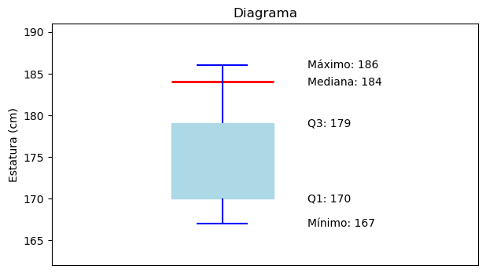

#### Solution

   **Datos de estaturas ordenados**

   | 167 | 174 |
   | --- | --- |
   | 168 | 175 |
   | 168 | 177 |
   | 169 | 177 |
   | 170 | 179 |
   | 172 | 180 |
   | 172 | 181 |
   | 173 | 184 |
   | 173 | 186 |
   | 174 |  |

   La opción correcta es aquella cuyo diagrama muestra exactamente estos valores:

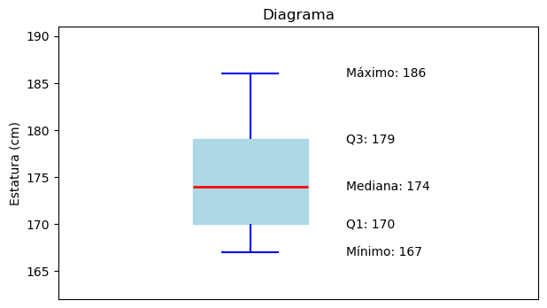

   1. Falso
   2. Falso
   3. Verdadero
   4. Falso

#### Question

10. En una clase de antropometría, se midió la estatura (en cm) de un grupo de estudiantes. Los datos obtenidos son:

    **Datos de estaturas**

    | 171 | 167 |
    | --- | --- |
    | 159 | 164 |
    | 159 | 161 |
    | 162 | 171 |
    | 159 | 164 |
    | 170 | 165 |
    | 164 | 163 |
    | 160 | 168 |
    | 156 | 163 |
    | 162 |  |

    ¿Cuál diagrama de caja representa correctamente estos datos?

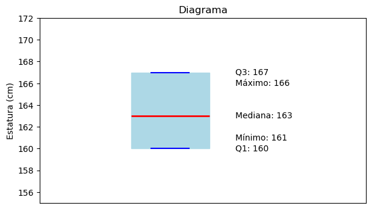

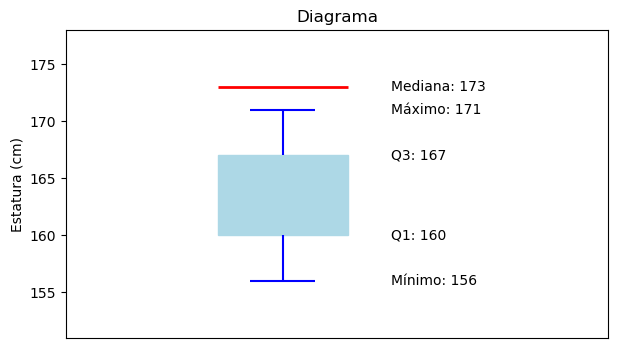

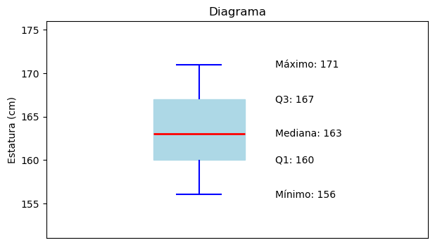

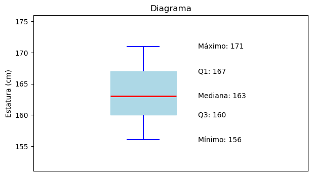

#### Solution

    **Datos de estaturas ordenados**

    | 156 | 164 |
    | --- | --- |
    | 159 | 164 |
    | 159 | 164 |
    | 159 | 165 |
    | 160 | 167 |
    | 161 | 168 |
    | 162 | 170 |
    | 162 | 171 |
    | 163 | 171 |
    | 163 |  |

    La opción correcta es aquella cuyo diagrama muestra exactamente estos valores:

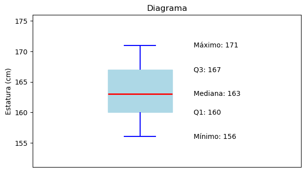

    1. Falso
    2. Falso
    3. Verdadero
    4. Falso